# FIT5197 Assessment 2

## Confidence Interval, Hypothesis Testing, Data Mining Models

### Student Name: Sadia Karim

### Student Number: 23386320

## Objectives

This assignment assesses your understanding of Confidence Interval, Hypothesis Testing, and Data Mining Models, covered in Modules 3 to 5. The total marks of this assessment is **100**, and has 30% contribution to your final score.

## Important Note

- You can complete your assignment using the codes shared in the unit (i.e. Alexandria, video, practical activities on Moodle) and this template as the bases. However, **you should make sure the codes you are using are correct and relevant to the question**.
- Please follow the structure of this template as much as you can.
- You can use the pre-populated codes cells or change them if you prefer. However, please **do not change the name of the key variables, functions, and parameters**. It helps us to read and understand your submission more efficiently.
- Submit your source code file in R notebook (this file with your answers) and a preview file (HTML or PDF). If the marker has problems to run your source codes, the preview file will be helpful.

## Question 1: Central Limit Theorem [20 marks]

## Instruction on presentation of Answer

The following question is an example and also how you should present your answers, omission of workings will result in loss of marks.

**Sample Question:**

There are $10,000$ students participate in an exam and the exam score approximately follow a normal distribution. Given that $359$ students get scores above $90$ in the exam and $1,151$ students get lower than $60$. If there are $2,500$ students pass the exam, find out the lowest score to pass.

**Sample Solution:**

Let $X$ represents the exam score and $X\sim N(\mu,\sigma^2)$

Additional Note: If there is a value for $\mu$ or $\sigma^2$ you are also required to write it down in the previous statement, in this case, there is no value so only the form is required. If the question asking you about central limit theorem (CLT) application or related to CLT application, you also need to state the form of CLT.

$\Rightarrow$ $\textbf{e.g.}$ $\overline{x}\sim \mathcal{N}(\text{some value},\text{some value})$. CLT is taught in the lectures in great details $\Rightarrow$ please follow the format properly.

`359` students get score above `90` $\Rightarrow$ $P(X > 90) = P \left( \frac{X - \mu}{\sigma} > \frac{90 - \mu}{\sigma} \right) = Pr \left(Z > \frac{90 - \mu}{\sigma} \right) = 0.0359$

Similarly, $P(X < 60) = P \left( \frac{X - \mu}{\sigma} < \frac{60 - \mu}{\sigma} \right) = Pr \left(Z < \frac{60 - \mu}{\sigma} \right) = 0.1151$

with $Z \sim \mathcal{N}(0,1)$

Looking up $\textbf{Z table}$, you can find that $\frac{90 - \mu}{\sigma} \approx 1.8$ and, $\frac{60 - \mu}{\sigma} \approx -1.2$

Soving for this, we can find that $\mu = 72, \sigma = 10$

Let k be the lowest score to pass and there are `2500` students pass the exam, then $P(X \geq k) = P \left( \frac{X - \mu}{\sigma} \geq \frac{k - \mu}{\sigma} \right) = Pr \left(Z \geq \frac{k - \mu}{\sigma} \right) = 0.25$

Looking up $\textbf{Z table}$, you can find that $\frac{k - \mu}{\sigma} \geq 0.67$. Given that $\mu = 72, \sigma = 10$, we will be able to calculate that $k \geq 78.7$.

Thus, the lowest score to pass is $78.7$

**All working answers for this part need to follow this structure to receive full marks**

1. The light bulb in Monash university has an average lifetime of $1,500$ hours with a standard deviation of $50$ hours. How many of these light bulbs should Monash stock up so that it can guarantee that the light will be on for at least $9,600$ hours with a probability of at least $97\%$? [5 marks]

Let $T$ be the “sum of total lightbulb hours” where $T\sim N(n\mu,n\sigma^2)$ (the sum version of the Central Limit Theorem (CLT)). We know from the question that $T = 9600$.

Let $n$ be the number of lightbulbs that Monash should stock up on. We are going to solve for $n$.

Other information we know:  
$\bullet$ $\mu = 1500$  
$\bullet$ $\sigma = 50$  
$\bullet$ $\phi(Z) = 0.97$

From the question, we know that $P(T>9600)=0.97$
We can write this in the standard normal format:
$$P\left( \frac{T-n\mu}{\sigma\sqrt{n}} > \frac{9600-n\mu}{50\sqrt{n}} \right) =0.97$$

So we end up with
$$P\left( Z > \frac{9600-n\mu}{50\sqrt{n}} \right) =0.97$$
Looking at the inside of the left hand side, we have the equation
$$Z > \frac{9600-n\mu}{50\sqrt{n}}$$
From the $\textbf{Z table}$ we can see that the Z-score that gives us $\approx0.97$ is $1.89$

Substituting in our known values we get the following:
$$1.89>\frac{9600-1500n}{50\sqrt{n}}$$
Rearranging this formula to solve for $n$ (I used Wolfram Alpha to solve this since the quadratic became very large and messy), we get that $n > 6.2426$.
Rounding this value up, Monash should stock up on $\textbf{7 lightbulbs}$

```r
n<-6
pnorm(9600, n*1500,50*sqrt(n))
```

```
## [1] 0.9999995
```

2. The error for the production of a machine is uniformly distributed over $[-0.5, 0.3]$ unit. Assuming that there are $200$ machines working at the same time, approximate the probability that the final total production differ from the exact total production by more than $5$ unit? [5 marks]

Let $X_i$ be the “error of the $i^{th}$ machine” where $X_i\sim U(a=-0.5,b=0.3)$  
We can calculate the following values:  
$\bullet$ $\mu_{X_i} = \frac{a+b}{2} = \frac{-0.5+0.3}{2} = -0.1$  
$\bullet$ $\sigma_{X_i}^2 = \frac{(b-a)^2}{12}=\frac{(0.3-(-0.5))^2}{12}\approx0.0533$  
$\bullet$ $\sigma_{X_i} = \sqrt{\sigma^2}\approx0.2309$

Assuming that the error of the machines are independent, let $E$ be the final total error for all $n=200$ machines. Therefore, $Y=X_1+X_2+...+X_n$ where we can apply the sum format of the CLT $E\sim N(n\mu,n\sigma^2)$ with:  
$\bullet$ $n\mu = 200(-0.1)=-20$  
$\bullet$ $n\sigma^2 = 200(0.0533)= 10.6667$  
$\bullet$ $\sqrt{n}\sigma = 3.2659$

Let $A$ be the event that the final total production differ from the exact total production by more than $5$ unit.

It follows from the CLT that $\frac{Y-n\mu}{\sqrt{n}\sigma}$ is approximately a standard normal variable. From the question we know that the total errors in the exact total production is $0$, so we are looking for $P(A) = P(Y>5) + P(Y<-5)$ Let us first look at $P(Y>5)$:
$$P(Y>5)=P \left( \frac{Y-n\mu}{\sqrt{n}\sigma} > \frac{5-n\mu}{\sqrt{n}\sigma} \right)$$
$$P(Y>5)=P \left( Z > \frac{5-(-20)}{3.2659} \right)$$
$$P(Y>5)=P \left( Z > 7.6548 \right)$$
Using R we find:

```r
gt5 <- 1-pnorm(7.6548)
gt5
```

```
## [1] 9.65894e-15
```

$$P(Z>7.6548) = 1-P(Z<7.6548) = 9.65894e-15$$
Let us now look at $P(Y<-5)$:
$$P(Y<-5)=P \left( \frac{Y-n\mu}{\sqrt{n}\sigma} < \frac{-5-n\mu}{\sqrt{n}\sigma} \right)$$
$$P(Y<-5)=P \left( Z < \frac{-5-(-20)}{3.2659} \right)$$
$$P(Y<-5)=P \left( Z < 4.5929 \right)$$
Using R we find:

```r
ltneg5 <- pnorm(4.5929)
ltneg5
```

```
## [1] 0.9999978
```

$$P(Z<4.5929)=0.9999978$$
Using the above two values we can now find $P(A)$

```r
gt5 + ltneg5
```

```
## [1] 0.9999978
```

3. Let $X \sim \mathcal{N}(\mu = 0, \sigma^2 = 1)$. Let $\textbf{n}$ be the number of observations we have, What would be the lowest value for $\textbf{n}$ such that $\operatorname{Pr}\left(\frac{X}{n} < \frac{1}{4}\right) \geq 0.98$. [5 marks]

By multiplying both sides of the LHS by $n$, we can see that $\frac{X}{n}>\frac{1}{4}$ is the same as of $X>\frac{n}{4}$, so we can find the value of $n$ using $X$ :

Since $X$ is already normally distributed about the mean, we can use $X$ directly when finding the Z value that gives us a probability of 0.98.
$$\operatorname{Pr}\left(X < \frac{n}{4}\right) = 0.98$$
From the table we can see that a Z value of $2.06$ gives us a probability of 0.98, so we can say that
$$\operatorname{Pr}\left(X < \frac{n}{4}\right) = \operatorname{Pr}\left(Z < 2.06\right)$$

4. [Dog-bites](https://www.ncbi.nlm.nih.gov/pmc/articles/PMC27561/), believed by many to happen more frequently during full-moon, is an interesting phenomenon that we would like to investigate in this question. The number of dog-bites in a full-moon day is believed to follow a `Poisson distribution`. In this question we will assume that the number of day-time dog-bites per hour in a full-moon day is follow a Poisson distribution with $\lambda = 5\;$, i.e. we can say that:$\;$ $\operatorname{Dog-bites}_{day}\;\sim\;\operatorname{Pois}\left(\lambda = 5\right)$
- Find the probability that the number of day-time dog-bites exceeds 3 bites ($3$ or more) in an hour for a full-moon day? [2 marks]

From the information we know $\operatorname {Dog-bites}_{day}\;\sim\;\operatorname{Pois}\left(\lambda = 5\right)$
We are looking for
$$P({Dog-bites}_{day} \geq 3) = 1 - \left( P({Dog-bites}_{day}=0) +P({Dog-bites}_{day}=1)+P({Dog-bites}_{day}=2) \right)$$

Substituting values into the Poisson distribution formula, we get:
$$P({Dog-bites}_{day} \geq 3) = 1-\left( \frac{5^0*e^{-5}}{0!}+\frac{5^1*e^{-5}}{1!}+\frac{5^2*e^{-5}}{2!}\right)\approx\textbf{0.8753}$$

- Night-time normally lasts for $60\%$ during a full-moon day. During night-time, the owners would normally lock up their dogs, reducing the chances of dog-bites. If this is the case, the average number of dog-bites per hour drops to $\boldsymbol{2}$ bites during night-time. If the number of dog-bites in a particular hour fails to reach $\boldsymbol{3}$ during day-time, what is the probability that this happens during night-time when the owners are more likely to lock up their dogs? [3 marks]

Let ${Dog-bites}_{night}$ be the number of dog bites at night-time, where ${Dog-bites}_{night}~Pois(\lambda=2)$
Let $A$ be the event the dog-bites fail to reach 3 in a particular hour From the information we can see that $P(Night)=0.6$ and $P(Day)=0.4$ where $Day$ can be considered as the complement of $Night$.
We are looking for the $P(Night|A)$
Using Bayes’ Theorem, we can calculate:
$$P(Night|A) = \frac{P(A|Night)P(Night)}{P(A|Night)P(Night) +P(A|Day)P(Day)}$$

## Question 2: Hypothesis Testing [10 marks]

Tom and Paul joined the chess club from their Grade 1 in primary school three years ago. They often play chess together to practice their skills. From 12 games recorded, Tom won 9 times and Paul won the rest ones. Tom thought he played better than Paul, but Paul thought Tom was just lucky.

1. Calculate an estimate of Tom’s winning rate at playing chess with Paul with a $95\%$ confidence interval. Show all working as required. [3 marks]

Assuming a binomial distribution, let $\hat p$ be the proportion of games that Tom wins. Therefore, $1 - \hat p$ represents the proportion of games that Paul wins (ie. games that Tom loses).

Since $n=12$, we can calculate:
$$\hat p = \frac{9}{12} = 0.75$$
$$1 -\hat p = \frac{3}{12} = 0.25$$

Applying CLT (even though the $n$ is small), a 95% confidence interval can be found using the formula:
$$\hat p \pm z_{0.025}\sqrt{\frac{\hat p (1- \hat p)}{n}}$$
We know that for 95% confidence, $z=1.96$, so substituting our known values into the equation we can get:
$$0.75 \pm 1.96\sqrt{\frac{0.75*0.25}{12}} = (0.505, 0.995)$$
So we can say with 95% confidence that Tom’s winning rate lies between $\textbf{(0.505,0.995)}$

2. Using hypothesis testing, test the hypothesis that Tom just got lucky, and the probability of wining is $50\%$ for both of them. Write down the hypothesis that you are testing, and then calculate a **p-value** using the approximate approach for testing a Bernoulli population. What does this **p-value** suggest? [7 marks]

The approximate approach for testing a Bernoulli population is to use the normal approximation to the binomial. Let us test a significance level of $\alpha=0.05$ If $X$ is the total number of games that Tom wins, then $X\sim Bin(n=12,p)$ where $p$ is the probability of winning a game.

We need to compute the probability that Tom would have won 9 or more games out of 12 when $p=0.5$.

We are testing to see if Tom’s winning rate is actually $50\%$, so we can state our null hypothesis as:
$$H_0: p = p_0$$
Our alternative hypothesis, based on our finding in part 1, states that Tom’s probability of winning is actually higher, so our alternative hypothesis can be stated as:
$$H_1: p \neq p_0$$
Assuming that $H_0$ is true, we can say that that $E(X)=np_0=6$ and $Var(X)=np_0(1-p_0)=3$ Therefore $X\sim Bin(12,0.5)$ and
$$\frac{X-np_0}{\sqrt{np_0(1-p_0)}} \sim N(0,1)$$
has an approximately standard normal distribution.

The p-value of a binomial two-tailed test of $X=9$ can be given by:
$$p-value = 2*min \{ P \{ X \leq 9\} ,P\{X \geq 9\}\}$$
We know that the mean is $6$, so we are looking for:
$$p-value=2P \{ X \geq 9\}$$
We can calculate $P\{ X \geq 9\}$ by applying the continuity correction and converting to the standard normal:
$$P_{0.5} \{ X \geq 9 \} = P_{0.5} \{ X \geq 8.5 \}$$
$$P_{0.5} \bigg\{ \frac{X-6}{\sqrt{3}} \geq \frac{8.5-6}{\sqrt{3}} \bigg\}$$
$$p-value = 2* P \{X \geq 1.4433 \}= 0.1489$$
Since this value is quite above our significance level of $0.05$, we cannot reject our null hypothesis at the 5% significance level.

We can also use R to calculate the actual p-value by running a binomial test

```r
binom.test(9, 12, p=0.5, alternative = "two.sided")
```

```
##
##  Exact binomial test
##
## data:  9 and 12
## number of successes = 9, number of trials = 12, p-value = 0.146
## alternative hypothesis: true probability of success is not equal to 0.5
## 95 percent confidence interval:
##  0.4281415 0.9451394
## sample estimates:
## probability of success
##                   0.75
```

We get an exact p-value of $0.146$ which is very close to our normal approximation $0.1489$ so again, we do not have enough support to reject our null hypothesis at the 5% significance level.

This p-value suggests that although a success rate of $p=0.5$ sits just outside the 95% confidence interval calculated in part 1, it is still significant enough at the 5% significance level that we cannot reject the claim that Tom’s success is due to luck.

## Question 3: Linear Regression and ANOVA [35 marks]

Use the **red wine** dataset from Assessment 1 ‘winequality-red.csv’. You are asked to predict the **quality** given the other variables. You are free to do any pre-processing to improve the quality of the datasets, i.e. remove outliers.

```
##  fixed.acidity   volatile.acidity  citric.acid    residual.sugar
##  Min.   : 4.60   Min.   :0.1200   Min.   :0.000   Min.   : 0.900
##  1st Qu.: 7.10   1st Qu.:0.3900   1st Qu.:0.090   1st Qu.: 1.900
##  Median : 7.90   Median :0.5200   Median :0.260   Median : 2.200
##  Mean   : 8.32   Mean   :0.5278   Mean   :0.271   Mean   : 2.539
##  3rd Qu.: 9.20   3rd Qu.:0.6400   3rd Qu.:0.420   3rd Qu.: 2.600
##  Max.   :15.90   Max.   :1.5800   Max.   :1.000   Max.   :15.500
##    chlorides       free.sulfur.dioxide total.sulfur.dioxide    density
##  Min.   :0.01200   Min.   : 1.00       Min.   :  6.00       Min.   :0.9901
##  1st Qu.:0.07000   1st Qu.: 7.00       1st Qu.: 22.00       1st Qu.:0.9956
##  Median :0.07900   Median :14.00       Median : 38.00       Median :0.9968
##  Mean   :0.08747   Mean   :15.87       Mean   : 46.47       Mean   :0.9967
##  3rd Qu.:0.09000   3rd Qu.:21.00       3rd Qu.: 62.00       3rd Qu.:0.9978
##  Max.   :0.61100   Max.   :72.00       Max.   :289.00       Max.   :1.0037
##        pH          sulphates         alcohol         quality
##  Min.   :2.740   Min.   :0.3300   Min.   : 8.40   Min.   :3.000
##  1st Qu.:3.210   1st Qu.:0.5500   1st Qu.: 9.50   1st Qu.:5.000
##  Median :3.310   Median :0.6200   Median :10.20   Median :6.000
##  Mean   :3.311   Mean   :0.6581   Mean   :10.42   Mean   :5.636
##  3rd Qu.:3.400   3rd Qu.:0.7300   3rd Qu.:11.10   3rd Qu.:6.000
##  Max.   :4.010   Max.   :2.0000   Max.   :14.90   Max.   :8.000
```

```
## [1] 0
```

```
## [1] 1599
```

Data has the same 12 variables, with Quality considered as the response variable, so I would expect to convert it to a factor when plotting my linear regressions. All other variables are numeric. There are no missing values.

1. Let **quality** be the dependent variable, based on your correlations analysis from Assessment 1, determine the best set of five independent variables that can be used to built linear regression models. [10 marks]

In Assessment 1 I chose not to remove outliers due to the fact that I do not know how or what caused these outliers and can’t confirm whether they are errors or not. If they are not errors, then removing them can introduce bias to the dataset. However, for the sake of this assessment, I have decided to remove them.

As shown in Assessment 1, below is my correlation map for all the variables.

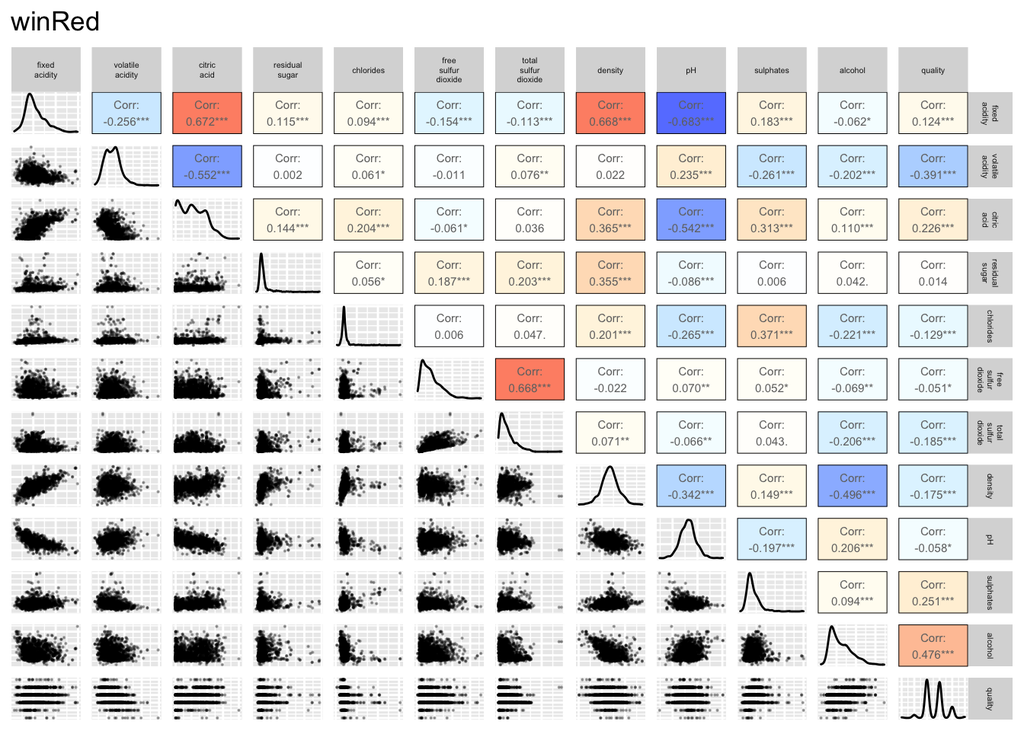

We can see that there are a number of variables that are heavily skewed, so we will remove the outliers from fixed acidity, volatile acidity, residual sugar, chlorides, free sulfur dioxide, total sulfur dioxide, sulphates and alcohol to see if I can get a more normal-looking distribution.

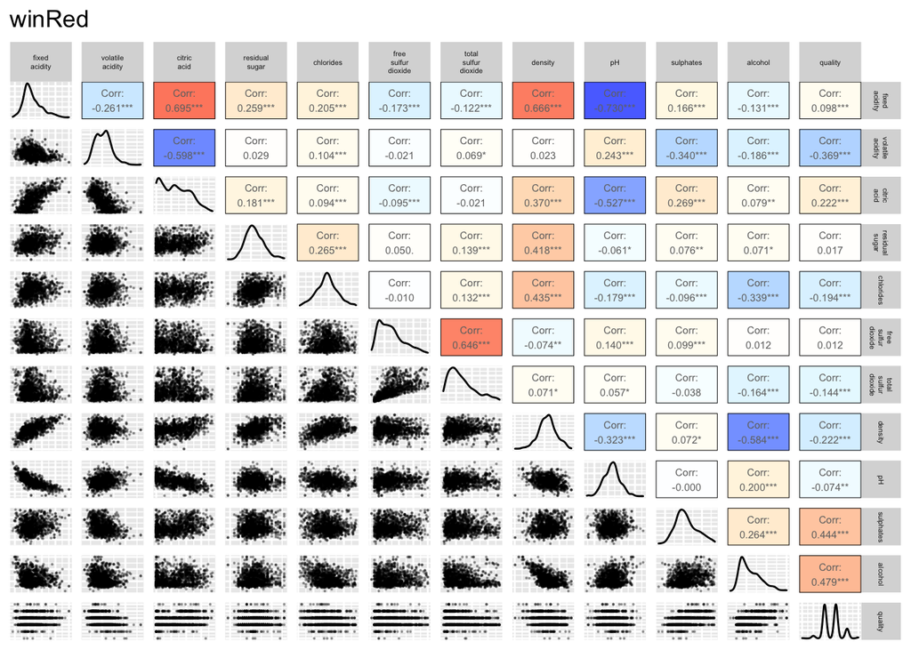

```
## [1] 1227
```

```r
## 75% of the sample size
smp_size <- floor(0.75 * nrow(winRedClean))

## set the seed to make your partition reproducible
set.seed(100)
train_ind <- sample(seq_len(nrow(winRedClean)), size = smp_size)

winRedTrain <- winRedClean[train_ind, ]
winRedTest <- winRedClean[-train_ind, ]
```

In Assessment 1, I identified the following variables as the top 5 having the most correlation with Quality (ordered by |r|):

1- Alcohol (0.476) 2- Volatile Acidity (-0.391) 3- Sulphates (0.251) 4- Citric Acid (0.226) 5- Total Sulfur Dioxide (-0.185)

However this is merely based upon the correlation coefficient. I will do a backward stepwise first to find the variables that have the most influence on quality.

```r
model <- lm(quality ~ ., data=winRedTrain)
smodel <- step(model)
```

```
## Start:  AIC=-895.07
## quality ~ fixed.acidity + volatile.acidity + citric.acid + residual.sugar +
##     chlorides + free.sulfur.dioxide + total.sulfur.dioxide +
##     density + pH + sulphates + alcohol
##
##                        Df Sum of Sq    RSS     AIC
## - fixed.acidity         1     0.052 338.84 -896.92
## - chlorides             1     0.207 339.00 -896.50
## - residual.sugar        1     0.367 339.16 -896.07
## - density               1     0.727 339.52 -895.09
## <none>                              338.79 -895.07
## - citric.acid           1     0.911 339.70 -894.60
## - free.sulfur.dioxide   1     1.480 340.27 -893.05
## - pH                    1     2.548 341.34 -890.17
## - total.sulfur.dioxide  1     2.659 341.45 -889.87
## - alcohol               1    13.786 352.58 -860.37
## - volatile.acidity      1    15.158 353.95 -856.80
## - sulphates             1    33.561 372.35 -810.17
##
## Step:  AIC=-896.92
## quality ~ volatile.acidity + citric.acid + residual.sugar + chlorides +
##     free.sulfur.dioxide + total.sulfur.dioxide + density + pH +
##     sulphates + alcohol
##
##                        Df Sum of Sq    RSS     AIC
## - chlorides             1     0.247 339.09 -898.25
## - residual.sugar        1     0.320 339.16 -898.06
## <none>                              338.84 -896.92
## - citric.acid           1     0.862 339.71 -896.59
## - density               1     1.064 339.91 -896.04
## - free.sulfur.dioxide   1     1.501 340.35 -894.86
## - total.sulfur.dioxide  1     2.835 341.68 -891.26
## - pH                    1     7.326 346.17 -879.25
## - volatile.acidity      1    15.107 353.95 -858.80
## - alcohol               1    21.001 359.85 -843.60
## - sulphates             1    33.561 372.41 -812.04
##
## Step:  AIC=-898.25
## quality ~ volatile.acidity + citric.acid + residual.sugar + free.sulfur.dioxide +
##     total.sulfur.dioxide + density + pH + sulphates + alcohol
```

[output cut: 12 more lines]

```
##
## Step:  AIC=-899.6
## quality ~ volatile.acidity + citric.acid + free.sulfur.dioxide +
##     total.sulfur.dioxide + density + pH + sulphates + alcohol
##
##                        Df Sum of Sq    RSS     AIC
## <none>                              339.33 -899.60
## - citric.acid           1     0.962 340.29 -899.00
## - density               1     1.061 340.39 -898.73
## - free.sulfur.dioxide   1     1.546 340.88 -897.42
## - total.sulfur.dioxide  1     2.750 342.08 -894.18
## - pH                    1     7.144 346.48 -882.43
## - volatile.acidity      1    15.295 354.63 -861.04
## - alcohol               1    29.630 368.96 -824.58
## - sulphates             1    33.778 373.11 -814.30
```

```r
summary(model)
```

```
##
## Call:
## lm(formula = quality ~ ., data = winRedTrain)
##
## Residuals:
##      Min       1Q   Median       3Q      Max
## -2.22568 -0.38236 -0.01693  0.41795  1.91884
##
## Coefficients:
##                        Estimate Std. Error t value Pr(>|t|)
## (Intercept)           50.307329  32.138366   1.565  0.11785
## fixed.acidity          0.012954   0.034799   0.372  0.70979
## volatile.acidity      -1.021502   0.160265  -6.374 2.93e-10 ***
## citric.acid           -0.299194   0.191512  -1.562  0.11857
## residual.sugar         0.059427   0.059915   0.992  0.32153
## chlorides             -1.254753   1.684412  -0.745  0.45651
## free.sulfur.dioxide    0.006319   0.003173   1.992  0.04671 *
## total.sulfur.dioxide  -0.003003   0.001125  -2.670  0.00773 **
## density              -45.763318  32.774205  -1.396  0.16296
## pH                    -0.668617   0.255881  -2.613  0.00912 **
## sulphates              1.929281   0.203424   9.484  < 2e-16 ***
## alcohol                0.235308   0.038711   6.079 1.78e-09 ***
## ---
## Signif. codes:  0 '***' 0.001 '**' 0.01 '*' 0.05 '.' 0.1 ' ' 1
##
## Residual standard error: 0.6108 on 908 degrees of freedom
## Multiple R-squared:  0.4004, Adjusted R-squared:  0.3931
## F-statistic: 55.11 on 11 and 908 DF,  p-value: < 2.2e-16
```

From the above we can see that the best model has 8 variables. However we are asked to find the top 5.

```r
x7 <- lm(quality~fixed.acidity + volatile.acidity + total.sulfur.dioxide +
    density + pH + sulphates + alcohol,data=winRedTrain)
summary(x7)
```

```
##
## Call:
## lm(formula = quality ~ fixed.acidity + volatile.acidity + total.sulfur.dioxide +
##     density + pH + sulphates + alcohol, data = winRedTrain)
##
## Residuals:
##      Min       1Q   Median       3Q      Max
## -2.26032 -0.37644 -0.03575  0.44016  1.91424
##
## Coefficients:
##                        Estimate Std. Error t value Pr(>|t|)
## (Intercept)           4.615e+01  2.559e+01   1.804  0.07161 .
## fixed.acidity        -9.422e-03  3.125e-02  -0.302  0.76310
## volatile.acidity     -8.890e-01  1.320e-01  -6.732 2.95e-11 ***
## total.sulfur.dioxide -1.699e-03  8.493e-04  -2.001  0.04571 *
## density              -4.170e+01  2.611e+01  -1.597  0.11063
## pH                   -6.453e-01  2.468e-01  -2.615  0.00908 **
## sulphates             1.991e+00  1.998e-01   9.962  < 2e-16 ***
## alcohol               2.453e-01  3.281e-02   7.476 1.79e-13 ***
## ---
## Signif. codes:  0 '***' 0.001 '**' 0.01 '*' 0.05 '.' 0.1 ' ' 1
##
## Residual standard error: 0.6126 on 912 degrees of freedom
## Multiple R-squared:  0.3943, Adjusted R-squared:  0.3896
## F-statistic:  84.8 on 7 and 912 DF,  p-value: < 2.2e-16
```

```r
x6 <- lm(quality~ volatile.acidity + total.sulfur.dioxide +
  density + pH + sulphates + alcohol,data=winRedClean)
summary(x6)
```

```
##
## Call:
## lm(formula = quality ~ volatile.acidity + total.sulfur.dioxide +
##     density + pH + sulphates + alcohol, data = winRedClean)
##
## Residuals:
##      Min       1Q   Median       3Q      Max
## -2.27430 -0.37675 -0.04381  0.45157  1.89427
##
## Coefficients:
##                        Estimate Std. Error t value Pr(>|t|)
## (Intercept)           3.847e+01  1.332e+01   2.887  0.00396 **
## volatile.acidity     -7.611e-01  1.129e-01  -6.742 2.41e-11 ***
## total.sulfur.dioxide -1.681e-03  7.233e-04  -2.324  0.02030 *
## density              -3.426e+01  1.315e+01  -2.606  0.00927 **
## pH                   -6.479e-01  1.312e-01  -4.937 9.05e-07 ***
## sulphates             2.055e+00  1.736e-01  11.841  < 2e-16 ***
## alcohol               2.542e-01  2.270e-02  11.199  < 2e-16 ***
## ---
## Signif. codes:  0 '***' 0.001 '**' 0.01 '*' 0.05 '.' 0.1 ' ' 1
##
## Residual standard error: 0.6144 on 1220 degrees of freedom
## Multiple R-squared:  0.3915, Adjusted R-squared:  0.3886
## F-statistic: 130.8 on 6 and 1220 DF,  p-value: < 2.2e-16
```

Again our F-statistic has increased and R-squared has gone down slightly. Next I will remove total.sulfur.dioxide as it has the highest p-value

```r
x5 <- lm(quality~ volatile.acidity + density + pH + sulphates + alcohol,data=winRedClean)
summary(x5)
```

```
##
## Call:
## lm(formula = quality ~ volatile.acidity + density + pH + sulphates +
##     alcohol, data = winRedClean)
##
## Residuals:
##      Min       1Q   Median       3Q      Max
## -2.21554 -0.37324 -0.05937  0.45936  1.92651
##
## Coefficients:
##                  Estimate Std. Error t value Pr(>|t|)
## (Intercept)       38.0485    13.3468   2.851  0.00443 **
## volatile.acidity  -0.7659     0.1131  -6.773 1.95e-11 ***
## density          -33.8977    13.1681  -2.574  0.01016 *
## pH                -0.6717     0.1311  -5.125 3.46e-07 ***
## sulphates          2.0481     0.1739  11.780  < 2e-16 ***
## alcohol            0.2619     0.0225  11.636  < 2e-16 ***
## ---
## Signif. codes:  0 '***' 0.001 '**' 0.01 '*' 0.05 '.' 0.1 ' ' 1
##
## Residual standard error: 0.6155 on 1221 degrees of freedom
## Multiple R-squared:  0.3889, Adjusted R-squared:  0.3864
## F-statistic: 155.4 on 5 and 1221 DF,  p-value: < 2.2e-16
```

So we now have our top 5 variables for quality based on backwards stepwise

This is quite interesting because from Assessment 1, I had identified Citric Acid in 4th place instead of pH, and the orders were mixed around a bit. This is to be expected though because A1 did include all the outliers, whereas I have removed them from this dataset. I will now do a forward stepwise to see if it produces something different. I will base it on p-values since that is what I used to decide which variables to remove above.

```r
model <- lm(quality~.,data=winRedClean)
ols_step_forward_p(model)
```

```
##
##                                    Selection Summary
## ---------------------------------------------------------------------------------------
##         Variable                              Adj.
## Step          Entered           R-Square    R-Square      C(p)         AIC        RMSE
## ---------------------------------------------------------------------------------------
##    1    alcohol                   0.2290      0.2284    323.8083    2576.1047    0.6902
##    2    sulphates                 0.3376      0.3365    107.9961    2391.8831    0.6400
##    3    volatile.acidity          0.3749      0.3733     35.1922    2322.8004    0.6220
##    4    pH                        0.3855      0.3835     15.8016    2303.6930    0.6169
##    5    citric.acid               0.3901      0.3876      8.5944    2296.4948    0.6149
##    6    total.sulfur.dioxide      0.3923      0.3893      6.2313    2294.1117    0.6140
##    7    density                   0.3931      0.3897      6.5340    2294.4024    0.6138
##    8    fixed.acidity             0.3937      0.3897      7.4003    2295.2593    0.6138
## ---------------------------------------------------------------------------------------
```

I will go with the forward stepwise results and have selected the top variables to be: 1- Alcohol 2- Sulphates 3- Volatile Acidity 4- pH 5- Citric Acid

From Assessment 1, I had assessed each of the variables independently and had discovered some that were dependent on others (total sulfur dioxide and free sulfur dioxide), however none of the identified variables (as far as I know) are dependent so we can use these for our linear regression models.

2. Use the best five independent variables from above to generate all possible linear regression models. Show the generated models in a table. [15 marks]

| model | r.squared | F.value | df.res |
| --- | --- | --- | --- |
| quality ~ alcohol | 0.22903020 | 363.907896 | 1,225 |
| quality ~ sulphates | 0.19714386 | 300.802609 | 1,225 |
| quality ~ volatile.acidity | 0.13628562 | 193.292937 | 1,225 |
| quality ~ pH | 0.00543309 | 6.691893 | 1,225 |
| quality ~ citric.acid | 0.04922823 | 63.426986 | 1,225 |
| quality ~ alcohol + sulphates | 0.33759351 | 311.903990 | 1,224 |
| quality ~ alcohol + volatile.acidity | 0.31024723 | 275.274433 | 1,224 |
| quality ~ alcohol + pH | 0.25888415 | 213.781821 | 1,224 |
| quality ~ alcohol + citric.acid | 0.26307281 | 218.475535 | 1,224 |
| quality ~ sulphates + volatile.acidity | 0.25092565 | 205.008357 | 1,224 |
| quality ~ sulphates + pH | 0.20256810 | 155.463651 | 1,224 |
| quality ~ sulphates + citric.acid | 0.20844452 | 161.161218 | 1,224 |
| quality ~ volatile.acidity + pH | 0.13656349 | 96.795598 | 1,224 |
| quality ~ volatile.acidity + citric.acid | 0.13628805 | 96.569562 | 1,224 |
| quality ~ pH + citric.acid | 0.05181521 | 33.443806 | 1,224 |
| quality ~ alcohol + sulphates + volatile.acidity | 0.37487774 | 244.472430 | 1,223 |
| quality ~ alcohol + sulphates + pH | 0.36150046 | 230.809386 | 1,223 |
| quality ~ alcohol + sulphates + citric.acid | 0.34819094 | 217.772114 | 1,223 |
| quality ~ alcohol + volatile.acidity + pH | 0.31903956 | 190.997580 | 1,223 |
| quality ~ alcohol + volatile.acidity + citric.acid | 0.31059127 | 183.661310 | 1,223 |
| quality ~ alcohol + pH + citric.acid | 0.27021104 | 150.942311 | 1,223 |
| quality ~ sulphates + volatile.acidity + pH | 0.25112439 | 136.705002 | 1,223 |
| quality ~ sulphates + volatile.acidity + citric.acid | 0.25171378 | 137.133781 | 1,223 |
| quality ~ sulphates + pH + citric.acid | 0.20878663 | 107.575719 | 1,223 |
| quality ~ volatile.acidity + pH + citric.acid | 0.13668831 | 64.545942 | 1,223 |
| quality ~ alcohol + sulphates + volatile.acidity + pH | 0.38553939 | 191.684024 | 1,222 |
| quality ~ alcohol + sulphates + volatile.acidity + citric.acid | 0.37492010 | 183.237522 | 1,222 |
| quality ~ alcohol + sulphates + pH + citric.acid | 0.36188200 | 173.251582 | 1,222 |
| quality ~ alcohol + volatile.acidity + pH + citric.acid | 0.32008715 | 143.822289 | 1,222 |
| quality ~ sulphates + volatile.acidity + pH + citric.acid | 0.25277801 | 103.347713 | 1,222 |
| quality ~ alcohol + sulphates + volatile.acidity + pH + citric.acid | 0.39012848 | 156.212203 | 1,221 |

3. Compare the all generated models and report the best one. You need to use common performance measurements to compare those models, i.e. Residuals versus Fitted, Normal Q-Q, scale-location, and residuals vs leverage. [10 marks]

```
##
## Call:
## lm(formula = quality ~ alcohol + sulphates + volatile.acidity +
##     pH + citric.acid, data = winRedTest)
##
## Residuals:
##      Min       1Q   Median       3Q      Max
## -1.76848 -0.40968 -0.06846  0.48353  1.90717
##
## Coefficients:
##                  Estimate Std. Error t value Pr(>|t|)
## (Intercept)       4.52365    1.07780   4.197 3.56e-05 ***
## alcohol           0.28625    0.03636   7.873 6.31e-14 ***
## sulphates         2.33628    0.34558   6.760 7.15e-11 ***
## volatile.acidity -0.41616    0.26281  -1.583  0.11436
## pH               -0.92061    0.31204  -2.950  0.00342 **
## citric.acid      -0.05499    0.29261  -0.188  0.85106
## ---
## Signif. codes:  0 '***' 0.001 '**' 0.01 '*' 0.05 '.' 0.1 ' ' 1
##
## Residual standard error: 0.6188 on 301 degrees of freedom
## Multiple R-squared:  0.399,  Adjusted R-squared:  0.389
## F-statistic: 39.97 on 5 and 301 DF,  p-value: < 2.2e-16
```

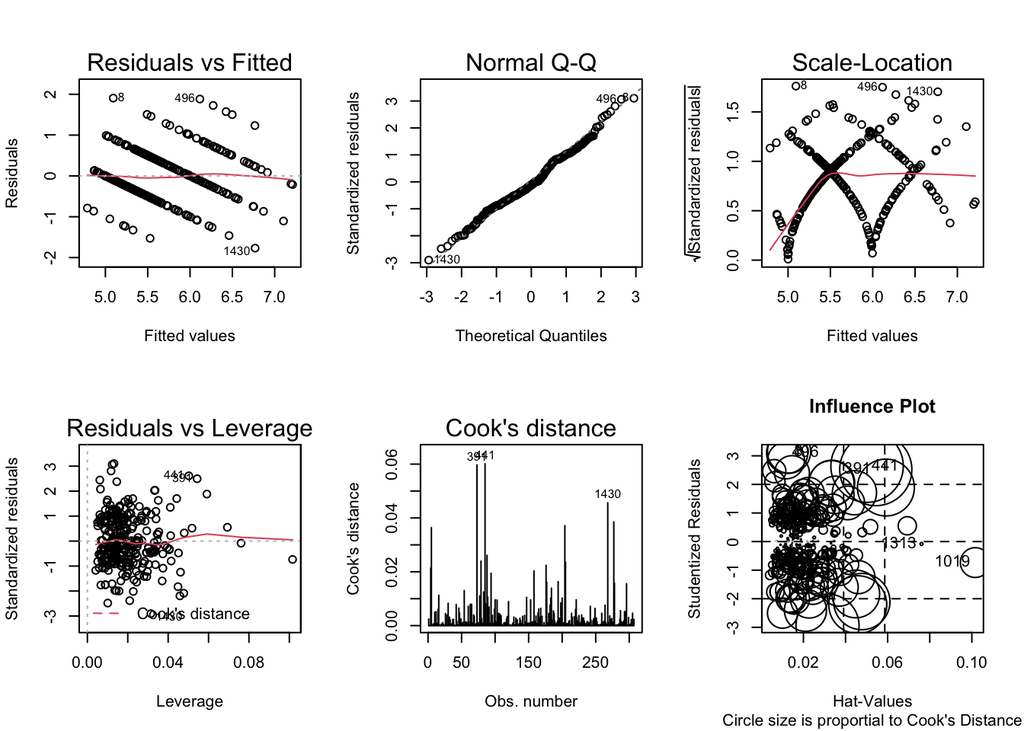

```
##          StudRes        Hat        CookD
## 8     3.14828105 0.01318900 2.144383e-02
## 391   2.51793215 0.05436497 5.968912e-02
## 441   2.63802704 0.05022725 6.014684e-02
## 496   3.10689847 0.01229193 1.946192e-02
## 1019 -0.73458494 0.10160973 1.018750e-02
## 1313 -0.08371579 0.07609917 9.652796e-05
```

##### R-Squared: 0.399

Not a great model, but not terrible. Citric acid has a very high p-value so I do not think it provides much information. Can be confirmed in the next graph where it is removed. F-statistic a little low but overall p-value very low so this is good.

##### Residuals vs Fitted Plot:

Linearity seems to hold in this case, the data points show that there is actually a very strong pattern visible, so perhaps linear is not the best model for this data. However, I know that all of the models produced a similar looking plot, so this is not unexpected.

##### Normal Q-Q:

Data appears to be normal, with very skinny tails

##### Scale Location Plot:

The red line (average magnitude of the standardized residuals) is not horizontal, so this suggests non-linearity That the spread around the red line doesn’t vary with the fitted values then the variability of magnitudes doesn’t vary much as a function of the fitted values.

##### Residual vs. Leverage Plot:

There is quite a bit of distortion around the red line so could indicated heteroskedasticity

##### Cook’s Distance & Influcence Plot:

There seems to be quite a few outliers and variables that seem to be influencing the graphs. Removing these values could make the fit of the model better.

```
##
## Call:
## lm(formula = quality ~ alcohol + sulphates + volatile.acidity +
##     pH, data = winRedTest)
##
## Residuals:
##      Min       1Q   Median       3Q      Max
## -1.76354 -0.40442 -0.07466  0.48317  1.91368
##
## Coefficients:
##                  Estimate Std. Error t value Pr(>|t|)
## (Intercept)       4.40936    0.88841   4.963 1.16e-06 ***
## alcohol           0.28523    0.03589   7.947 3.83e-14 ***
## sulphates         2.32456    0.33937   6.850 4.15e-11 ***
## volatile.acidity -0.39103    0.22591  -1.731 0.084491 .
## pH               -0.88899    0.26238  -3.388 0.000797 ***
## ---
## Signif. codes:  0 '***' 0.001 '**' 0.01 '*' 0.05 '.' 0.1 ' ' 1
##
## Residual standard error: 0.6178 on 302 degrees of freedom
## Multiple R-squared:  0.399,  Adjusted R-squared:  0.391
## F-statistic: 50.12 on 4 and 302 DF,  p-value: < 2.2e-16
```

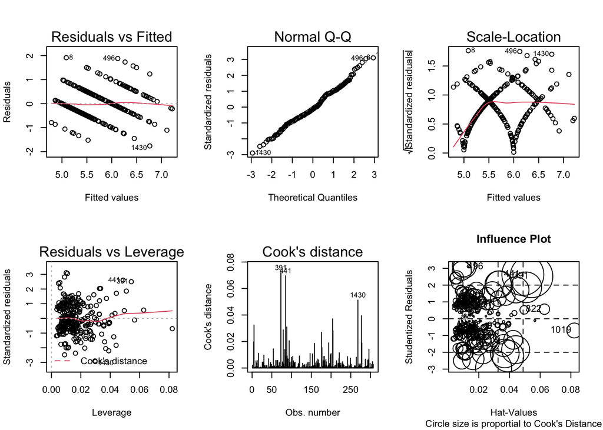

```
##         StudRes        Hat       CookD
## 8     3.1592744 0.01005671 0.019693528
## 391   2.5226869 0.05435153 0.071877462
## 441   2.6323590 0.04871520 0.069603347
## 496   3.1021159 0.01087278 0.020568738
## 822   0.5673061 0.06276616 0.004320349
## 1019 -0.7005718 0.08223671 0.008810553
```

##### R-Squared: 0.399

Same value as the previous model so citric acid is not a crucial variable for our model. Volatile acidity has the highest p-value so maybe this is also not as crucial. F-statistic is higher in this model with a low p-value, so I would this that f2 is better than fit1.

##### Residuals vs Fitted Plot:

Linearity seems to hold in this case, however same as the previous in that there is a distinct pattern in the data.

###### Normal Q-Q:

Data appears to be normal which is good

##### Scale Location Plot:

The red line (average magnitude of the standardized residuals) is not horizontal, so this suggests non-linearity especially at the beginning, however it seems to plateau later - could indicate a potentially expontial relationship?

##### Residual vs. Leverage Plot:

Again plot is very distorted and appears to be increasing so perhaps there is some heteroskedasticity

##### Cook’s Distance & Influcence Plot:

Quite a large number of extreme outliers here that are skewing and affecting the model. We could remove them for a better fit.

```
##
## Call:
## lm(formula = quality ~ alcohol + sulphates + volatile.acidity +
##     citric.acid, data = winRedTest)
##
## Residuals:
##      Min       1Q   Median       3Q      Max
## -1.75051 -0.42245 -0.09779  0.44576  1.94437
##
## Coefficients:
##                  Estimate Std. Error t value Pr(>|t|)
## (Intercept)       1.60806    0.43562   3.691 0.000265 ***
## alcohol           0.26757    0.03626   7.380 1.54e-12 ***
## sulphates         2.17047    0.34531   6.286 1.14e-09 ***
## volatile.acidity -0.35431    0.26529  -1.336 0.182703
## citric.acid       0.41048    0.24956   1.645 0.101053
## ---
## Signif. codes:  0 '***' 0.001 '**' 0.01 '*' 0.05 '.' 0.1 ' ' 1
##
## Residual standard error: 0.6266 on 302 degrees of freedom
## Multiple R-squared:  0.3817, Adjusted R-squared:  0.3735
## F-statistic:  46.6 on 4 and 302 DF,  p-value: < 2.2e-16
```

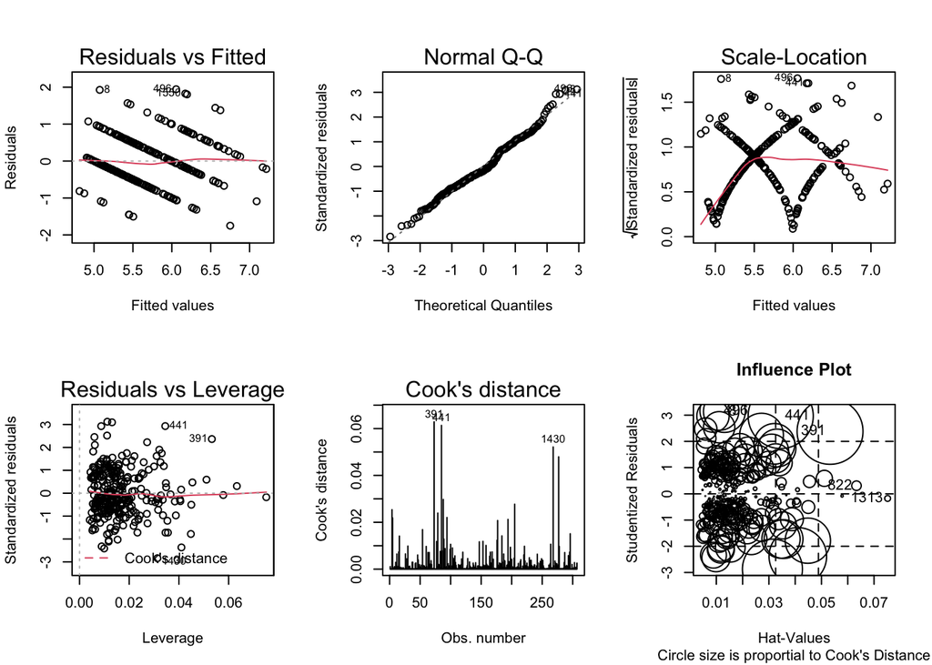

```
##         StudRes        Hat        CookD
## 8     3.1397224 0.01307734 0.0253801372
## 391   2.3819730 0.05326156 0.0628662884
## 441   2.9680441 0.03449395 0.0613579852
## 496   3.1667425 0.01118926 0.0220369123
## 822   0.3106499 0.06331649 0.0013085720
## 1313 -0.1751849 0.07516277 0.0005004454
```

##### R-Squared: 0.3817

This has performed worse than the previous graphs so again not a great model. Volatile acidity has a slightly higher p-value as does citric acid, so perhaps these are not as significant. F-statistic is slightly lower in this model, however still has a low p-value so this is ok. fit2 is still better in terms of summary.

##### Residuals vs Fitted Plot:

Linearity seems to hold in this case, however same as the previous in that there is a distinct pattern in the data.

##### Normal Q-Q:

Data appears normal with some skinny tails on the normal distribution

##### Scale Location Plot:

The red line (average magnitude of the standardized residuals) is not horizontal, so this suggests non-linearity. Again could be an exponential relationship

##### Residual vs. Leverage Plot:

Plot is more fitted to the 0 line than the previous models, so perhaps a better model in terms of homoskedasticity

##### Cook’s Distance & Influcence Plot:

Not as many extreme outliers in this diagram and the ones that are, seem to have little influence on the graph. Perhaps not worth removing

```
##
## Call:
## lm(formula = quality ~ alcohol + sulphates + volatile.acidity,
##     data = winRedTest)
##
## Residuals:
##      Min       1Q   Median       3Q      Max
## -1.79595 -0.41378 -0.08986  0.44674  2.01238
##
## Coefficients:
##                  Estimate Std. Error t value Pr(>|t|)
## (Intercept)       1.75702    0.42730   4.112 5.06e-05 ***
## alcohol           0.27157    0.03628   7.486 7.76e-13 ***
## sulphates         2.23388    0.34411   6.492 3.46e-10 ***
## volatile.acidity -0.59631    0.22137  -2.694  0.00746 **
## ---
## Signif. codes:  0 '***' 0.001 '**' 0.01 '*' 0.05 '.' 0.1 ' ' 1
##
## Residual standard error: 0.6284 on 303 degrees of freedom
## Multiple R-squared:  0.3761, Adjusted R-squared:  0.3699
## F-statistic: 60.89 on 3 and 303 DF,  p-value: < 2.2e-16
```

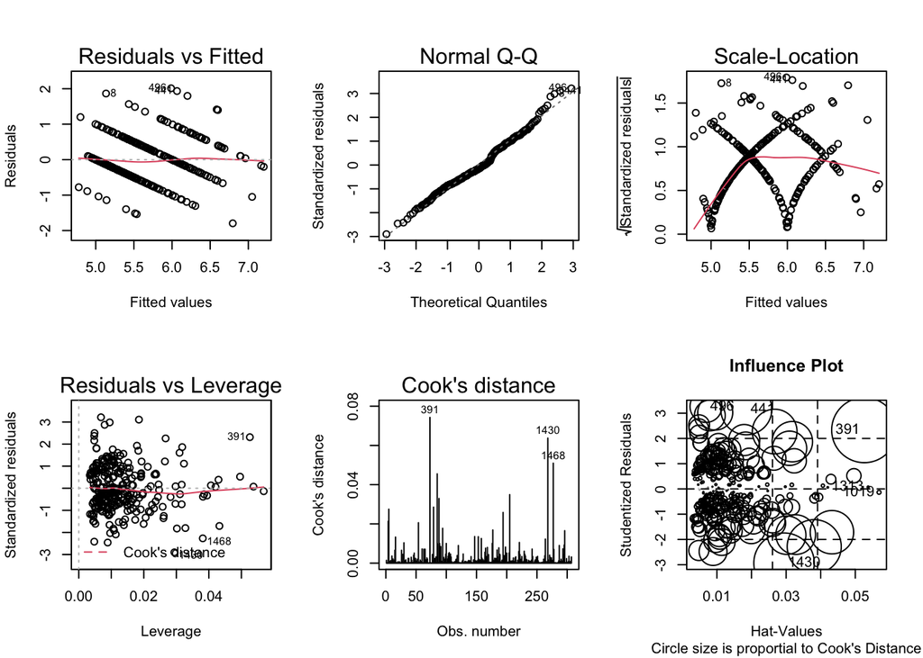

```
##          StudRes         Hat        CookD
## 391   2.32998496 0.052605230 7.427492e-02
## 441   3.15318708 0.018498614 4.550464e-02
## 496   3.26427489 0.006834731 1.776601e-02
## 1019 -0.13342232 0.056864018 2.691970e-04
## 1313  0.07382798 0.053714903 7.760374e-05
## 1430 -2.93731652 0.029402377 6.373632e-02
```

##### R-Squared: 0.3761

Similar performance to the previous graph however the F-statistic is the highest in this model! The independent variables have lower p-values in this model, so are all highly significant, and overall p-value is very low so this is a good model!

##### Residuals vs Fitted Plot:

Linearity seems to hold in this case, however same as the previous in that there is a distinct pattern in the data.

##### Normal Q-Q:

Data appears normal with skinny tails

##### Scale Location Plot:

The red line (average magnitude of the standardized residuals) is not horizontal, so this suggests non-linearity.

##### Residual vs. Leverage Plot:

Some slight distortion of the graph but overall ok, so potentially indicative of homoskedasticity

##### Cook’s Distance & Influcence Plot:

Quite a few outliers in this graph, a few of which have quite a lot of influence. We should remove them.

```
##
## Call:
## lm(formula = quality ~ alcohol + sulphates + pH, data = winRedTest)
##
## Residuals:
##      Min       1Q   Median       3Q      Max
## -1.69762 -0.40773 -0.05113  0.47211  1.91245
##
## Coefficients:
##             Estimate Std. Error t value Pr(>|t|)
## (Intercept)  4.41779    0.89132   4.956 1.20e-06 ***
## alcohol      0.29263    0.03575   8.185 7.63e-15 ***
## sulphates    2.51507    0.32208   7.809 9.50e-14 ***
## pH          -1.01078    0.25360  -3.986 8.43e-05 ***
## ---
## Signif. codes:  0 '***' 0.001 '**' 0.01 '*' 0.05 '.' 0.1 ' ' 1
##
## Residual standard error: 0.6198 on 303 degrees of freedom
## Multiple R-squared:  0.393,  Adjusted R-squared:  0.387
## F-statistic: 65.39 on 3 and 303 DF,  p-value: < 2.2e-16
```

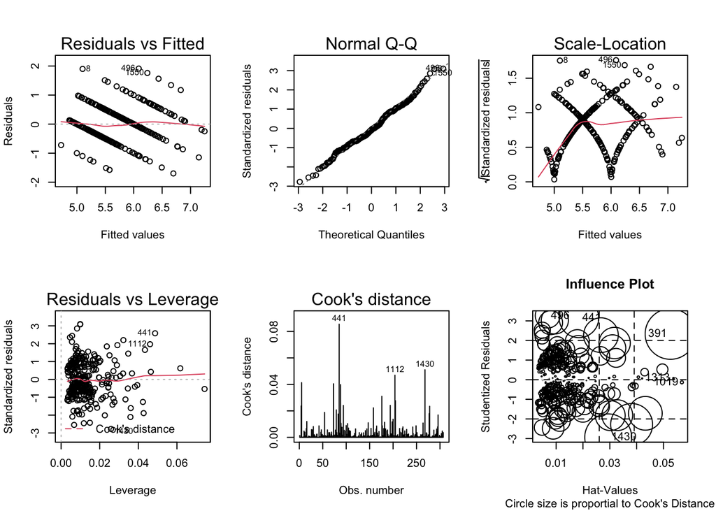

[output not shown]

##### Residuals vs Fitted Plot:

Linearity seems to hold in this case, however same as the previous in that there is a distinct pattern in the data.

##### Normal Q-Q:

Data appears quite normal with skinny tails

##### Scale Location Plot:

The red line (average magnitude of the standardized residuals) is not horizontal, so this suggests non-linearity.

##### Cook’s Distance & Influcence Plot:

Quite a few outliers in this graph, a few of which have quite a lot of influence. We should remove them.

#### Summary

It should be noted that for all of the residuals vs. fitted models there is a very distinct pattern between the variables, so technically these variables should not be plotted using a linear model. However based on the diagnostic graphs, I have assessed that fit4: quality ~ alcohol + sulphates + volatile.acidity produces the most accurate model. Even though fit5 has a slightly higher r-squared value and F-statistic, the residual vs. fitted graph performs more poorly so I think fit4 performs the best for a linear regression.

## Question 4: Logistic Regression [35 marks]

Use the **white wine** dataset modified from Assessment 1 ‘winequality-white.csv’ in the assessment 2 package. The quality variable contains only two values: 0 - low quality; and 1 - high quality. You are asked to predict the **quality** given the other variables.

1.Data Pre-Processing. (i.e. removal of null values; numeralisation of factor features/independent varilables). You need to split the dataset into a training set and a test set. Provide the reason why you think your split ratio will produce the best result. [5 marks]

```
##  fixed.acidity    volatile.acidity  citric.acid     residual.sugar
##  Min.   : 3.800   Min.   :0.0800   Min.   :0.0000   Min.   : 0.600
##  1st Qu.: 6.300   1st Qu.:0.2100   1st Qu.:0.2700   1st Qu.: 1.700
##  Median : 6.800   Median :0.2600   Median :0.3200   Median : 5.200
##  Mean   : 6.855   Mean   :0.2782   Mean   :0.3342   Mean   : 6.391
##  3rd Qu.: 7.300   3rd Qu.:0.3200   3rd Qu.:0.3900   3rd Qu.: 9.900
##  Max.   :14.200   Max.   :1.1000   Max.   :1.6600   Max.   :65.800
##
##    chlorides       free.sulfur.dioxide total.sulfur.dioxide    density
##  Min.   :0.00900   Min.   :  2.00      Min.   :  9.0        Min.   :0.9871
##  1st Qu.:0.03600   1st Qu.: 23.00      1st Qu.:108.0        1st Qu.:0.9917
##  Median :0.04300   Median : 34.00      Median :134.0        Median :0.9937
##  Mean   :0.04577   Mean   : 35.31      Mean   :138.4        Mean   :0.9940
##  3rd Qu.:0.05000   3rd Qu.: 46.00      3rd Qu.:167.0        3rd Qu.:0.9961
##  Max.   :0.34600   Max.   :289.00      Max.   :440.0        Max.   :1.0390
##  NA's   :3
##        pH          sulphates         alcohol         quality
##  Min.   :2.720   Min.   :0.2200   Min.   : 8.00   Min.   :0.0000
##  1st Qu.:3.090   1st Qu.:0.4100   1st Qu.: 9.50   1st Qu.:0.0000
##  Median :3.180   Median :0.4700   Median :10.40   Median :1.0000
##  Mean   :3.188   Mean   :0.4898   Mean   :10.51   Mean   :0.6652
##  3rd Qu.:3.280   3rd Qu.:0.5500   3rd Qu.:11.40   3rd Qu.:1.0000
##  Max.   :3.820   Max.   :1.0800   Max.   :14.20   Max.   :1.0000
##
```

```
## [1] 3
```

```
## [1] 0
```

```
## 'data.frame':    4895 obs. of  12 variables:
##  $ fixed.acidity       : num  7 8.1 7.2 7.2 8.1 6.2 7 6.3 8.1 8.1 ...
##  $ volatile.acidity    : num  0.27 0.28 0.23 0.23 0.28 0.32 0.27 0.3 0.22 0.27 ...
##  $ citric.acid         : num  0.36 0.4 0.32 0.32 0.4 0.16 0.36 0.34 0.43 0.41 ...
##  $ residual.sugar      : num  20.7 6.9 8.5 8.5 6.9 7 20.7 1.6 1.5 1.45 ...
##  $ chlorides           : num  0.045 0.05 0.058 0.058 0.05 0.045 0.045 0.049 0.044 0.033 ...
##  $ free.sulfur.dioxide : num  45 30 47 47 30 30 45 14 28 11 ...
##  $ total.sulfur.dioxide: num  170 97 186 186 97 136 170 132 129 63 ...
##  $ density             : num  1.001 0.995 0.996 0.996 0.995 ...
##  $ pH                  : num  3 3.26 3.19 3.19 3.26 3.18 3 3.3 3.22 2.99 ...
##  $ sulphates           : num  0.45 0.44 0.4 0.4 0.44 0.47 0.45 0.49 0.45 0.56 ...
##  $ alcohol             : num  8.8 10.1 9.9 9.9 10.1 9.6 8.8 9.5 11 12 ...
##  $ quality             : int  1 1 1 1 1 1 1 1 1 0 ...
##  - attr(*, "na.action")= 'omit' Named int [1:3] 2 17 179
##   ..- attr(*, "names")= chr [1:3] "2" "17" "179"
```

```
##  fixed.acidity    volatile.acidity  citric.acid     residual.sugar
##  Min.   : 3.800   Min.   :0.0800   Min.   :0.0000   Min.   : 0.600
##  1st Qu.: 6.300   1st Qu.:0.2100   1st Qu.:0.2700   1st Qu.: 1.700
##  Median : 6.800   Median :0.2600   Median :0.3200   Median : 5.200
##  Mean   : 6.855   Mean   :0.2781   Mean   :0.3343   Mean   : 6.395
##  3rd Qu.: 7.300   3rd Qu.:0.3200   3rd Qu.:0.3900   3rd Qu.: 9.900
##  Max.   :14.200   Max.   :1.1000   Max.   :1.6600   Max.   :65.800
##    chlorides       free.sulfur.dioxide total.sulfur.dioxide    density
##  Min.   :0.00900   Min.   :  2.00      Min.   :  9.0        Min.   :0.9871
##  1st Qu.:0.03600   1st Qu.: 23.00      1st Qu.:108.0        1st Qu.:0.9917
##  Median :0.04300   Median : 34.00      Median :134.0        Median :0.9937
##  Mean   :0.04577   Mean   : 35.32      Mean   :138.4        Mean   :0.9940
##  3rd Qu.:0.05000   3rd Qu.: 46.00      3rd Qu.:167.0        3rd Qu.:0.9961
##  Max.   :0.34600   Max.   :289.00      Max.   :440.0        Max.   :1.0390
##        pH          sulphates         alcohol      quality
##  Min.   :2.720   Min.   :0.2200   Min.   : 8.00   0:1639
##  1st Qu.:3.090   1st Qu.:0.4100   1st Qu.: 9.50   1:3256
##  Median :3.180   Median :0.4700   Median :10.40
##  Mean   :3.188   Mean   :0.4899   Mean   :10.52
##  3rd Qu.:3.280   3rd Qu.:0.5500   3rd Qu.:11.40
##  Max.   :3.820   Max.   :1.0800   Max.   :14.20
```

The more data that the model has to train on, the more accurate it will be so I have done a 80:20 split, but the numbers in the test set were a little smaller than I would have liked. Of course, ideally I would be able to use all of the data to train the model, but the aim is to assess the accuracy of the model. I think 80:20 should yield a fairly accurate model.

```
##
##    0    1
## 1311 2604
```

```
##
##   0   1
## 328 652
```

2.Built a logistic regression model on the training data. You need to determine which factor feature(s)/independent variable(s) to use based on the **p-values** analysis. Report the **best** logistic regression model. [15 marks]

Provide your answer and your explanation here.

```
##
## Call:
## glm(formula = quality ~ ., family = "binomial", data = winWhiteTrain)
##
## Deviance Residuals:
##     Min       1Q   Median       3Q      Max
## -3.1730  -0.8965   0.4421   0.7948   2.5335
##
## Coefficients:
##                        Estimate Std. Error z value Pr(>|z|)
## (Intercept)           1.910e+02  7.457e+01   2.562  0.01041 *
## fixed.acidity         1.078e-03  7.739e-02   0.014  0.98888
## volatile.acidity     -6.471e+00  4.625e-01 -13.991  < 2e-16 ***
## citric.acid          -7.692e-02  3.383e-01  -0.227  0.82011
## residual.sugar        1.423e-01  2.885e-02   4.933 8.11e-07 ***
## chlorides             1.597e+00  1.834e+00   0.871  0.38375
## free.sulfur.dioxide   1.171e-02  3.140e-03   3.732  0.00019 ***
## total.sulfur.dioxide -2.356e-03  1.355e-03  -1.739  0.08209 .
## density              -2.028e+02  7.560e+01  -2.683  0.00731 **
## pH                    8.900e-01  3.959e-01   2.248  0.02457 *
## sulphates             1.739e+00  3.988e-01   4.361 1.30e-05 ***
## alcohol               8.094e-01  9.916e-02   8.163 3.27e-16 ***
## ---
## Signif. codes:  0 '***' 0.001 '**' 0.01 '*' 0.05 '.' 0.1 ' ' 1
##
## (Dispersion parameter for binomial family taken to be 1)
##
##     Null deviance: 4992.2  on 3914  degrees of freedom
## Residual deviance: 3947.7  on 3903  degrees of freedom
## AIC: 3971.7
##
## Number of Fisher Scoring iterations: 5
```

fixed.acidity has the highest p-value so I will remove it next.

```
##
## Call:
## glm(formula = quality ~ alcohol + sulphates + pH + density +
##     total.sulfur.dioxide + free.sulfur.dioxide + chlorides +
##     residual.sugar + citric.acid + volatile.acidity, family = "binomial",
##     data = winWhiteTrain)
##
## Deviance Residuals:
##     Min       1Q   Median       3Q      Max
## -3.1731  -0.8963   0.4420   0.7949   2.5335
##
## Coefficients:
##                        Estimate Std. Error z value Pr(>|z|)
## (Intercept)           1.903e+02  5.131e+01   3.709 0.000208 ***
## alcohol               8.103e-01  7.584e-02  10.685  < 2e-16 ***
## sulphates             1.738e+00  3.941e-01   4.410 1.03e-05 ***
## pH                    8.863e-01  2.917e-01   3.039 0.002376 **
## density              -2.020e+02  5.150e+01  -3.923 8.75e-05 ***
## total.sulfur.dioxide -2.357e-03  1.352e-03  -1.744 0.081217 .
## free.sulfur.dioxide   1.172e-02  3.139e-03   3.732 0.000190 ***
## chlorides             1.593e+00  1.802e+00   0.884 0.376867
## residual.sugar        1.421e-01  2.061e-02   6.892 5.50e-12 ***
## citric.acid          -7.642e-02  3.363e-01  -0.227 0.820260
## volatile.acidity     -6.472e+00  4.598e-01 -14.075  < 2e-16 ***
## ---
## Signif. codes:  0 '***' 0.001 '**' 0.01 '*' 0.05 '.' 0.1 ' ' 1
##
## (Dispersion parameter for binomial family taken to be 1)
##
##     Null deviance: 4992.2  on 3914  degrees of freedom
## Residual deviance: 3947.7  on 3904  degrees of freedom
## AIC: 3969.7
##
## Number of Fisher Scoring iterations: 5
```

AIC and BIC have both improved. Remove citric.acid next as they have the highest p-values.

```
##
## Call:
## glm(formula = quality ~ alcohol + sulphates + pH + density +
##     total.sulfur.dioxide + free.sulfur.dioxide + chlorides +
##     residual.sugar + volatile.acidity, family = "binomial", data = winWhiteTrain)
##
## Deviance Residuals:
##     Min       1Q   Median       3Q      Max
## -3.1745  -0.8942   0.4425   0.7937   2.5366
##
## Coefficients:
##                        Estimate Std. Error z value Pr(>|z|)
## (Intercept)           1.928e+02  5.017e+01   3.842 0.000122 ***
## alcohol               8.072e-01  7.461e-02  10.819  < 2e-16 ***
## sulphates             1.735e+00  3.939e-01   4.405 1.06e-05 ***
## pH                    9.021e-01  2.833e-01   3.184 0.001450 **
## density              -2.046e+02  5.031e+01  -4.067 4.77e-05 ***
## total.sulfur.dioxide -2.354e-03  1.352e-03  -1.741 0.081659 .
## free.sulfur.dioxide   1.167e-02  3.130e-03   3.727 0.000194 ***
## chlorides             1.554e+00  1.794e+00   0.866 0.386311
## residual.sugar        1.429e-01  2.026e-02   7.056 1.71e-12 ***
## volatile.acidity     -6.458e+00  4.559e-01 -14.167  < 2e-16 ***
## ---
## Signif. codes:  0 '***' 0.001 '**' 0.01 '*' 0.05 '.' 0.1 ' ' 1
##
## (Dispersion parameter for binomial family taken to be 1)
##
##     Null deviance: 4992.2  on 3914  degrees of freedom
## Residual deviance: 3947.8  on 3905  degrees of freedom
## AIC: 3967.8
##
## Number of Fisher Scoring iterations: 5
```

There is overall improvement. Remove chlorides next as they have the highest p-values.

```
##
## Call:
## glm(formula = quality ~ alcohol + sulphates + pH + density +
##     total.sulfur.dioxide + free.sulfur.dioxide + residual.sugar +
##     volatile.acidity, family = "binomial", data = winWhiteTrain)
##
## Deviance Residuals:
##     Min       1Q   Median       3Q      Max
## -3.1221  -0.8953   0.4431   0.7933   2.5379
##
## Coefficients:
##                        Estimate Std. Error z value Pr(>|z|)
## (Intercept)           1.901e+02  5.011e+01   3.793 0.000149 ***
## alcohol               7.974e-01  7.375e-02  10.812  < 2e-16 ***
## sulphates             1.729e+00  3.938e-01   4.391 1.13e-05 ***
## pH                    8.809e-01  2.822e-01   3.121 0.001801 **
## density              -2.016e+02  5.023e+01  -4.014 5.98e-05 ***
## total.sulfur.dioxide -2.363e-03  1.352e-03  -1.748 0.080442 .
## free.sulfur.dioxide   1.179e-02  3.128e-03   3.770 0.000163 ***
## residual.sugar        1.406e-01  2.008e-02   7.004 2.49e-12 ***
## volatile.acidity     -6.418e+00  4.530e-01 -14.167  < 2e-16 ***
## ---
## Signif. codes:  0 '***' 0.001 '**' 0.01 '*' 0.05 '.' 0.1 ' ' 1
##
## (Dispersion parameter for binomial family taken to be 1)
##
##     Null deviance: 4992.2  on 3914  degrees of freedom
## Residual deviance: 3948.5  on 3906  degrees of freedom
## AIC: 3966.5
##
## Number of Fisher Scoring iterations: 5
```

Remove total.sulfur.dioxide next as it has the highest p-value

```
##
## Call:
## glm(formula = quality ~ alcohol + sulphates + pH + density +
##     free.sulfur.dioxide + residual.sugar + volatile.acidity,
##     family = "binomial", data = winWhiteTrain)
##
## Deviance Residuals:
##     Min       1Q   Median       3Q      Max
## -3.1071  -0.9045   0.4423   0.8012   2.7504
##
## Coefficients:
##                       Estimate Std. Error z value Pr(>|z|)
## (Intercept)          2.125e+02  4.910e+01   4.328 1.50e-05 ***
## alcohol              7.935e-01  7.454e-02  10.646  < 2e-16 ***
## sulphates            1.651e+00  3.898e-01   4.236 2.28e-05 ***
## pH                   8.923e-01  2.818e-01   3.167 0.001542 **
## density             -2.244e+02  4.917e+01  -4.563 5.05e-06 ***
## free.sulfur.dioxide  8.535e-03  2.498e-03   3.417 0.000634 ***
## residual.sugar       1.468e-01  1.988e-02   7.381 1.57e-13 ***
## volatile.acidity    -6.580e+00  4.451e-01 -14.781  < 2e-16 ***
## ---
## Signif. codes:  0 '***' 0.001 '**' 0.01 '*' 0.05 '.' 0.1 ' ' 1
##
## (Dispersion parameter for binomial family taken to be 1)
##
##     Null deviance: 4992.2  on 3914  degrees of freedom
## Residual deviance: 3951.6  on 3907  degrees of freedom
## AIC: 3967.6
##
## Number of Fisher Scoring iterations: 5
```

Seems to be a good final set of variables as they all have very low p-values. I also tried to remove the slightly larger ones to see if I can get an improvement in AIC or BIC but it resulted in increasing the AIC and BIC, so $\textbf{l4}$ is the final model I will go with.

3.Evaluate the trained model on the test set. [15 marks]

```
##  798 3197 4604 4632 4523  754
##    1    1    1    1    0    1
```

```
##          actual
## predicted    0    1
##         0 1040  886
##         1  271 1718
```

```
## [1] 0.70447
```

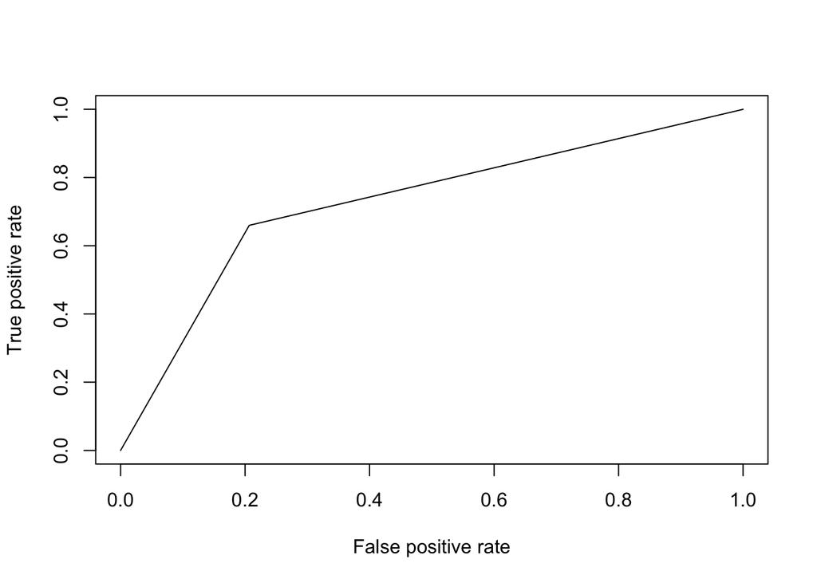

```
## [1] 0.7265209
```

So our Binomial Logistic Regression gives a training set accuracy of $\approx 70.44\%$ and AUC value of $0.727$

Now lets apply to test data.

```
##          actual
## predicted   0   1
##         0 264 225
##         1  64 427
```

```
## [1] 0.705102
```

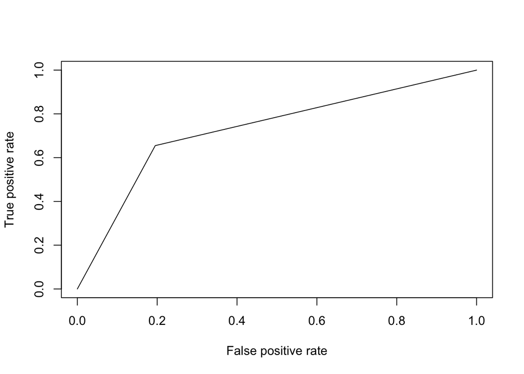

```
## [1] 0.729893
```

```
## [1] 0.8647186
```